# simulation-plots

### Vulnerability ratios vs revenue stream with prices as constants

- in the top plots, $p_w$ = 1
- in the bottom plots, $p_s$ = 1

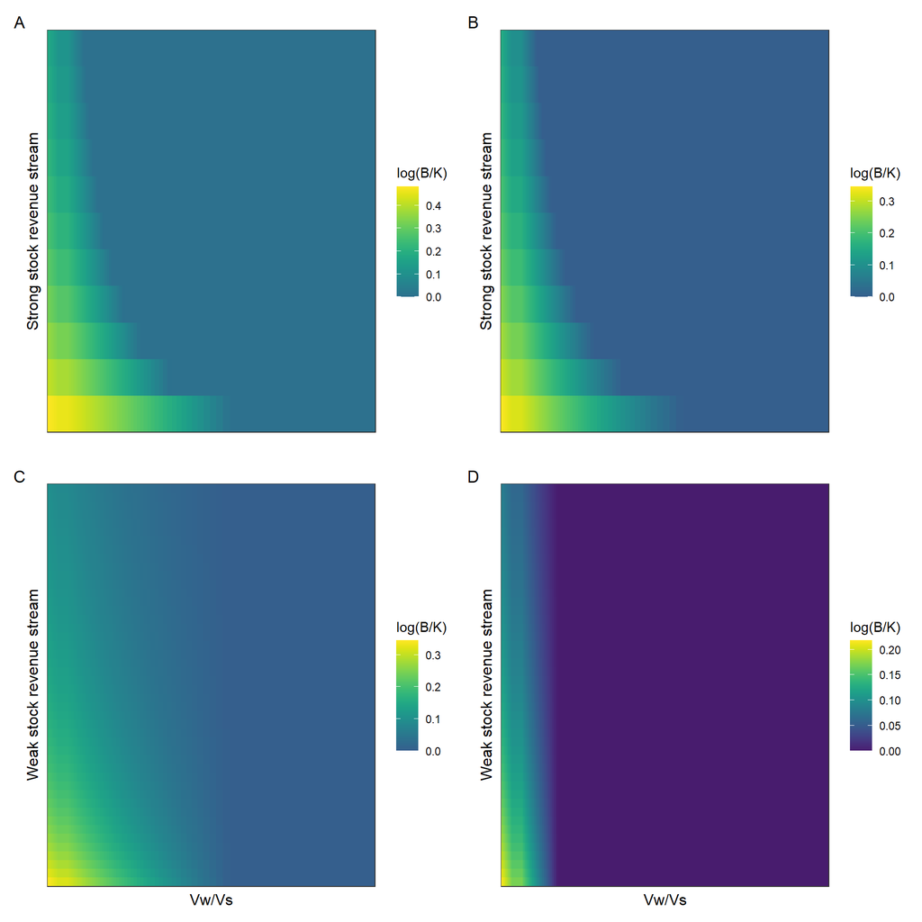

```
## # A tibble: 2 × 4
##   extinct      n  prop   sum
##   <chr>    <int> <dbl> <dbl>
## 1 no       33528  18.0   100
## 2 yes     152772  82.0   100
```

```
## # A tibble: 2 × 4
##   extinct      n  prop   sum
##   <chr>    <int> <dbl> <dbl>
## 1 no       67482  36.2   100
## 2 yes     118818  63.8   100
```

## Fisheries subsidy analyses

- 0.045 = 10% subsidy
- 0.0375 = 25% subsidy
- 0.025 = 50% subsidy
- 0.045 = 10% subsidy
- 0.0375 = 25% subsidy
- 0.025 = 50% subsidy

```
## # A tibble: 2 × 4
##   extinct      n  prop   sum
##   <chr>    <int> <dbl> <dbl>
## 1 no       31740 0.170     1
## 2 yes     154560 0.830     1
```

```
## # A tibble: 2 × 4
##   extinct      n  prop   sum
##   <chr>    <int> <dbl> <dbl>
## 1 no       49634 0.266     1
## 2 yes     136666 0.734     1
```

```
## # A tibble: 2 × 4
##   extinct      n  prop   sum
##   <chr>    <int> <dbl> <dbl>
## 1 no       60352 0.324     1
## 2 yes     125948 0.676     1
```

## Time series equations

$$\begin{align}
\frac{d N_s}{dt} &= N_S r_s (1 - (\frac{N_S}{K_s})) - q_s E \\
\newline
\frac{d N_w}{dt} &= N_W r_w (1 - (\frac{N_W}{K_w})) - q_w E \\
\newline
\frac{d E}{dt} &= \alpha E (p_s q_s N_S + p_w q_w N_W - c)
\newline
\frac{d C_s}{dt} &= q_s N_s E
\newline
\frac{d C_w}{dt} &= q_w N_w E
\newline
\frac{d CPUE_s}{dt} &= \frac{C_s} {E}
\newline
\frac{d CPUE_w}{dt} &= \frac{C_w} {E}
\newline
\frac{d \pi_s}{dt} &= C_s p_s - C_s c
\newline
\frac{d \pi_w}{dt} &= C_w p_W - C_w c
\newline
\frac{d \pi}{dt} &= C_s p_s + C_w p_w - (C_s + C_w) * c
\end{align}$$

where $q_s$ and $q_w$ are the catchability of the strong and the weak stock, respectively; $r_s$ and $r_w$ are the intrinsic growth rates of the strong and weak stocks, respectively; $p_s$ and $p_w$ are the prices of the strong and weak stocks, respectively; $k_s$ and $k_w$ are the carrying capacities of the strong and weak stocks, respectively; $c$ is the fishing cost, and $\alpha$ is a constant controling for the speed at which effort changes following price changes.

### Prices as constants

Parameter space for equilibrium points

[output not shown]

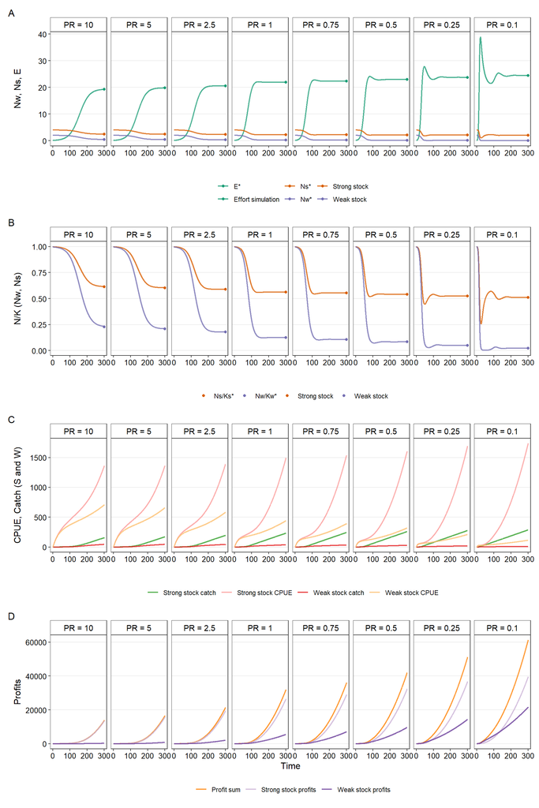

Panel A shows the time series dynamics for the strong and weak stocks, and effort. Panel B shows the same data but without effort for better comparison. Panel C shows the CPUE and catch for the strong and weak stocks separately. Panel D shows the profits for the strong and weak stocks, and the total profits for the fishery through time.